# Logistic Regression

Shritama Sengupta

2023-06-08

### 1. Explain about the data in words.

#### The “Weekly” dataset is a financial dataset that typically contains information about weekly stock market returns and other related variables. It may include features such as stock prices, trading volumes, market indices, and potentially additional financial indicators. It is important to refer to the documentation or description of the dataset to gain a comprehensive understanding of the specific variables and their meanings.

```r
library(corrplot)
library(ISLR2)
data(Weekly)
df = Weekly
head(df)
```

```
##   Year   Lag1   Lag2   Lag3   Lag4   Lag5    Volume  Today Direction
## 1 1990  0.816  1.572 -3.936 -0.229 -3.484 0.1549760 -0.270      Down
## 2 1990 -0.270  0.816  1.572 -3.936 -0.229 0.1485740 -2.576      Down
## 3 1990 -2.576 -0.270  0.816  1.572 -3.936 0.1598375  3.514        Up
## 4 1990  3.514 -2.576 -0.270  0.816  1.572 0.1616300  0.712        Up
## 5 1990  0.712  3.514 -2.576 -0.270  0.816 0.1537280  1.178        Up
## 6 1990  1.178  0.712  3.514 -2.576 -0.270 0.1544440 -1.372      Down
```

### 2. Produce some numerical and graphical summaries of the Weekly data.

Do there appear to be any patterns?

```r
summary(Weekly)
```

```
##       Year           Lag1               Lag2               Lag3
##  Min.   :1990   Min.   :-18.1950   Min.   :-18.1950   Min.   :-18.1950
##  1st Qu.:1995   1st Qu.: -1.1540   1st Qu.: -1.1540   1st Qu.: -1.1580
##  Median :2000   Median :  0.2410   Median :  0.2410   Median :  0.2410
##  Mean   :2000   Mean   :  0.1506   Mean   :  0.1511   Mean   :  0.1472
##  3rd Qu.:2005   3rd Qu.:  1.4050   3rd Qu.:  1.4090   3rd Qu.:  1.4090
##  Max.   :2010   Max.   : 12.0260   Max.   : 12.0260   Max.   : 12.0260
##       Lag4               Lag5              Volume            Today
##  Min.   :-18.1950   Min.   :-18.1950   Min.   :0.08747   Min.   :-18.1950
##  1st Qu.: -1.1580   1st Qu.: -1.1660   1st Qu.:0.33202   1st Qu.: -1.1540
##  Median :  0.2380   Median :  0.2340   Median :1.00268   Median :  0.2410
##  Mean   :  0.1458   Mean   :  0.1399   Mean   :1.57462   Mean   :  0.1499
##  3rd Qu.:  1.4090   3rd Qu.:  1.4050   3rd Qu.:2.05373   3rd Qu.:  1.4050
##  Max.   : 12.0260   Max.   : 12.0260   Max.   :9.32821   Max.   : 12.0260
##  Direction
##  Down:484
##  Up  :605
##
##
##
##
```

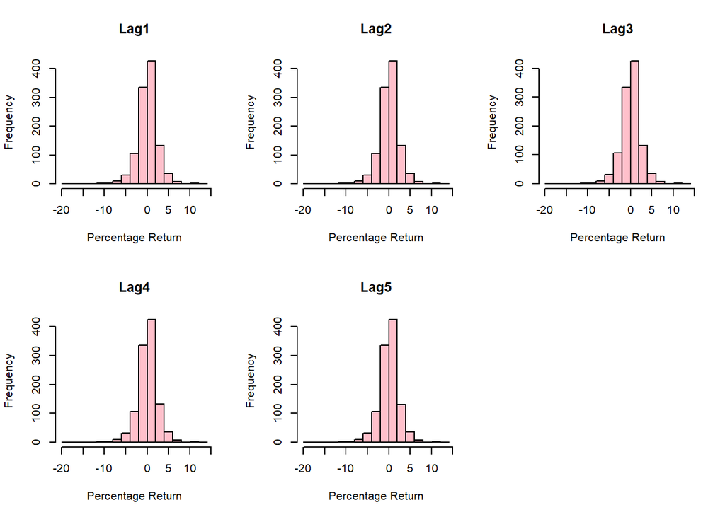

```r
# Histogram of Lag Variables
par(mfrow = c(2, 3))  # To create a grid of multiple plots
hist(df$Lag1, main = "Lag1", xlab = "Percentage Return", col = "pink")
hist(df$Lag2, main = "Lag2", xlab = "Percentage Return", col = "pink")
hist(df$Lag3, main = "Lag3", xlab = "Percentage Return", col = "pink")
hist(df$Lag4, main = "Lag4", xlab = "Percentage Return", col = "pink")
hist(df$Lag5, main = "Lag5", xlab = "Percentage Return", col = "pink")
```

### 3. Split the data set as train and test with train data period from 1990 to 2008 and the remaining period from 2009 onwards in test.

```r
# Subset the data for the training set (1990-2008)
train_data <- df[df$Year <= 2008, ]

# Subset the data for the test set (2009 onwards)
test_data <- df[df$Year > 2008, ]
```

### 4.Use the train data set to perform a logistic regression with Direction as the response and the five lag variables plus Volume as predictors.Use the summary function to print the results. Do any of the predictors appear to be statistically significant? If so, which ones?

```r
# Perform logistic regression
model <- glm(Direction ~ Lag1 + Lag2 + Lag3 + Lag4 + Lag5 + Volume, data = train_data, family = binomial)

# Print the summary of the model
summary(model)
```

```
##
## Call:
## glm(formula = Direction ~ Lag1 + Lag2 + Lag3 + Lag4 + Lag5 +
##     Volume, family = binomial, data = train_data)
##
## Deviance Residuals:
##     Min       1Q   Median       3Q      Max
## -1.7186  -1.2498   0.9823   1.0841   1.4911
##
## Coefficients:
##             Estimate Std. Error z value Pr(>|z|)
## (Intercept)  0.33258    0.09421   3.530 0.000415 ***
## Lag1        -0.06231    0.02935  -2.123 0.033762 *
## Lag2         0.04468    0.02982   1.499 0.134002
## Lag3        -0.01546    0.02948  -0.524 0.599933
## Lag4        -0.03111    0.02924  -1.064 0.287241
## Lag5        -0.03775    0.02924  -1.291 0.196774
## Volume      -0.08972    0.05410  -1.658 0.097240 .
## ---
## Signif. codes:  0 '***' 0.001 '**' 0.01 '*' 0.05 '.' 0.1 ' ' 1
##
## (Dispersion parameter for binomial family taken to be 1)
##
##     Null deviance: 1354.7  on 984  degrees of freedom
## Residual deviance: 1342.3  on 978  degrees of freedom
## AIC: 1356.3
##
## Number of Fisher Scoring iterations: 4
```

```r
#From the summary, we can see that some predictors have statistically significant effects on the response variable (Direction) at a significance level of 0.05:The intercept term (Intercept) has a significant effect with a p-value of 0.000415.
#Lag1 is also significant with a p-value of 0.033762.
#The remaining predictors, Lag2, Lag3, Lag4, Lag5, and Volume, do not appear to be statistically significant as their p-values are greater than 0.05.
#These results suggest that Lag1 has a statistically significant impact on the direction of the stock market, while the other lag variables and volume do not have a significant effect in this logistic regression model.
```

### 5.Compute the confusion matrix and overall fraction of correct predictions for the train set. Explain what the confusion matrix is telling you about the types of mistakes made by logistic regression. Also compute the recall value, accuracy, precision and F-score for the train set.

```r
# Make predictions on the train set
train_predictions <- predict(model, newdata = train_data, type = "response")

# Convert predicted probabilities to predicted classes (0 or 1)
train_predicted_classes <- ifelse(train_predictions > 0.5, 1, 0)

# Create a confusion matrix
confusion_matrix <- table(Actual = train_data$Direction, Predicted = train_predicted_classes)

# Compute overall fraction of correct predictions
accuracy <- sum(diag(confusion_matrix)) / sum(confusion_matrix)

# Compute recall (true positive rate), precision, and F-score
TP <- confusion_matrix[2, 2]
FP <- confusion_matrix[1, 2]
TN <- confusion_matrix[1, 1]
FN <- confusion_matrix[2, 1]

recall <- TP / (TP + FN)
precision <- TP / (TP + FP)
F_score <- 2 * (precision * recall) / (precision + recall)

# Print the confusion matrix and performance metrics
print(confusion_matrix)
```

```
##       Predicted
## Actual   0   1
##   Down  80 361
##   Up    70 474
```

```r
print(paste("Accuracy:", accuracy))
```

```
## [1] "Accuracy: 0.56243654822335"
```

```r
print(paste("Recall:", recall))
```

```
## [1] "Recall: 0.871323529411765"
```

```r
print(paste("Precision:", precision))
```

```
## [1] "Precision: 0.567664670658683"
```

```r
print(paste("F-score:", F_score))
```

```
## [1] "F-score: 0.687454677302393"
```